# Simulation-based Bias Analysis (`sim.BA`)

Rishi Desai, Noah Greifer

This is a vignette for `sim.BA`. This package conducts individual level simulations that can allow researchers to characterize the bias arising from unmeasured confounding with a specified but modifiable structure during the study design. Time-to-event outcomes are generated in simulated datasets based on user-specified treatment and outcome prevalence and other related variables including unmeasured confounders and their measured proxies. Results are summarized quantitatively to evaluate balance and bias when conducting analyses that do not account for unmeasured confounding (Level 1 adjustment) versus when accounting for unmeasured confounding through measured proxies (Level 2 adjustment).

```r
library(sim.BA)
```

### Creating a parameters file

First, a user can create the `parameters` object that will be supplied to `simBA()` containing the parameters for the simulation design.

```r
parameters <- create_parameters(nbinary = 6,
                                ncontinuous = 1,
                                ncount = 1,
                                # file = "parameters.csv",
                                unmeasured_conf = "u1",
                                unmeasured_type = "binary")

# Note: uncomment `file` argument to automatically save file to supplied path
```

The user can manually fill in the parameter values in the csv file. An example file comes with the package, which we can load in using the following:

```r
parameters <- read.csv(system.file("extdata", "parameters.csv",
                                   package = "sim.BA"))

parameters
```

```
#>    Variable                        Description       Type prevalence mean  sd
#> 1        c1                             Gender     binary       0.21   NA  NA
#> 2        c2                                Age continuous         NA   77 7.6
#> 3        c3            GI complication history     binary       0.03   NA  NA
#> 4        c4 Concurrent GI protective agent use     binary       0.21   NA  NA
#> 5        c5               Warfarin use history     binary       0.08   NA  NA
#> 6        c6         Number of hospitalizations      count         NA    8  NA
#> 7        c7              Gastric ulcer history     binary       0.14   NA  NA
#> 8        c8                       OA diagnosis     binary       0.35   NA  NA
#> 9        c9                       RA diagnosis     binary       0.04   NA  NA
#> 10      c10    GI protective agent use history     binary       0.28   NA  NA
#> 11      c11  Any hospital admission in the CAP     binary       0.18   NA  NA
#> 12      c12                               COPD     binary       0.15   NA  NA
#> 13      c13         Corticosteroid use history     binary       0.07   NA  NA
#> 14       u1                         Unmeasured     binary       0.10   NA  NA
#>    coeff_treatment_model coeff_outcome_model
#> 1                -0.2783             0.46667
#> 2                 0.0321             0.07803
#> 3                 0.1660             1.03895
#> 4                 0.0910            -0.68778
#> 5                 0.5499             0.23121
#> 6                 0.0110             0.05539
#> 7                 0.0488                  NA
#> 8                 0.4507                  NA
#> 9                 0.5488                  NA
#> 10                0.1569                  NA
#> 11               -0.0435                  NA
#> 12                    NA             0.24222
#> 13                    NA            -0.13412
#> 14                1.0000             1.00000
```

A representative directed acyclic graph (DAG) for data generation for the simulation study used in this vignette is shown below. Users are encouraged to use DAGs to explicitly convey design of their own simulations.

[figure not shown]

### Running simulations using `simBA()`

The following table provides guidance on how to design your simulations using various options available in the `simBA()` function.

[output not shown]

```r
sim <- simBA(parameters,
             iterations = 500,
             size = 1000,
             treatment_prevalence = .2,
             treatment_coeff = -.5,
             outcome_prevalence = .05,
             dist = "weibull",
             unmeasured_conf = "u1",
             n_proxies = 2,
             proxy_type = "binary",
             corr = c(0.5, 0.4),
             adj = "matching",
             adj_args = list(method = "nearest", caliper=0.2),
             estimand = "ATT",
             keep_data = FALSE,
             # cl = 4, #uncomment for speed on Mac
             verbose = FALSE)
sim
```

```
#> A `simBA` object
#>  - sample size: 1000
#>  - treatment prevalence: 0.2
#>  - treatment coefficient: -0.5 (true HR: 0.62)
#>  - outcome prevalence: 0.05
#>  - outcome distribution: Weibull
#>  - unmeasured confounder: "u1"
#>  - proxies: 2 (binary; r = 0.5, 0.4)
#>  - adjustment method: matching
#> Use `summary()` and `plot()` to examine results.
```

### Reviewing the results

```r
summary(sim)
```

```
#> - Average Standardized Mean Difference (SMD):
#>  Variable Adjustment       SMD
#>        p1      crude  0.144646
#>        p1         L1  0.147536
#>        p1         L2 -0.000214
#>        p2      crude  0.123846
#>        p2         L1  0.122237
#>        p2         L2  0.001030
#>        u1      crude  0.273600
#>        u1         L1  0.276043
#>        u1         L2  0.191818
#>
#> - Hazard Ratios (HR):
#>  Adjustment    HR
#>       crude 0.734
#>          L1 0.667
#>          L2 0.640
#>        true 0.616
```

The summary provides numerical results for key metrics including balance (standardized mean differences) and hazard ratios averaged over all simulation iterations.

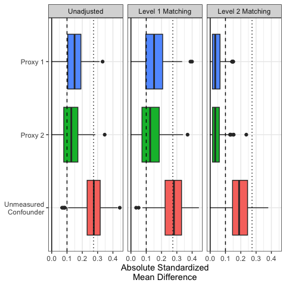

```r
plot(sim, type = "balance")
```

The balance plot provides distribution of absolute standardized mean differences (SMD) in the unmeasured confounder and proxies (when included) over the simulation runs. Vertical lines are placed at 0 (solid) to denote perfect balance, 0.1 (dashed) to denote ‘reasonable’ balance, and at the crude SMD for the unmeasured confounder (dotted). As you go from the unadjusted (which does not adjust for any confounding) to Level 1 (which only adjusts for measured confounding), large imbalances remain in the unmeasured confounder and proxies between treatment groups. Including proxies of unmeasured confounding in adjustment Level 2, excellent balance is achieved in the included proxies and imbalance also reduces for the unmeasured confounder due to correlations with the proxies.

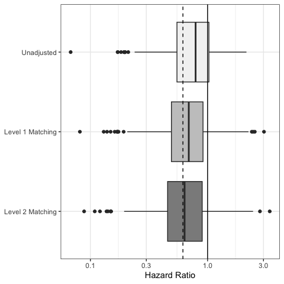

```r
plot(sim, type = "hr")
```

The hazard ratio (HR) plot plots hazard ratios on a log scale for the x-axis. Vertical lines are placed at 1 (solid) and the true marginal HR (dashed). As you go from the unadjusted to Level 1 and Level 2, the distribution shifts closer to the simulated truth suggesting that accounting for unmeasured confounding through proxies in Level 2 helps in reducing the threat of unmeasured confounding.

We can request a similar plot that displays the relative bias of the HR estimates (`(est_HR - true_HR) / true_HR`) by setting `type = "bias"`.

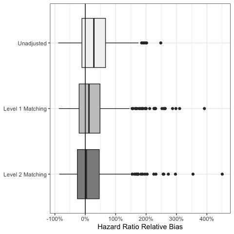

```r
plot(sim, type = "bias")
```

See `?plot.simBA` for further details.